# CSCI E-63C: Final Exam

# Preface

For the final exam/project we will develop classification models using several approaches and compare their performance on a new dataset – so-called “Census Income” from UCI ML. It is available at UCI ML web site, but so that we are not at the mercy of UCI ML availability, there is also a local copy of it in our website in Canvas as a zip-archive of all associated files. Among other things, the description for this dataset also presents performance (prediction accuracy) observed by the dataset providers using variety of modeling techniques – this supplies a context for the errors of the models we will develop here.

Please note that the original data has been split up into training and test subsets, but there doesn’t seem to be anything particular about that split, so we might want to pool those two datasets together and split them into training and test as necessary ourselves. As you do that, please check that the attribute levels are consistent between those two files. For instance, the categorized income levels are indicated using slightly different notation in their training and test data. By now it should be quite straightforward for you to correct that when you pool them together.

Also, please note that there is non-negligible number of rows with missing values that for most analyses cannot be included without modification in the computation. Please decide how you want to handle them and proceed accordingly. The simplest and perfectly acceptable approach would be to exclude those observations from the rest of the analyses, but if you have time and inclination to investigate the impact of imputing them by various means, you are welcome to try.

Attribute called “final weight” in the dataset description represents demographic weighting of these observations. Please disregard it for the purposes of this assignment.

Additionally, several attributes in this dataset are categorical variables with more than two levels (e.g. native country, occupation, etc.). Please make sure to translate them into corresponding sets of dummy indicator variables for the methods that require such conversion (e.g. PCA) – R function `model.matrix` can be convenient for this, instead of generating those 0/1 indicators for each level of the factor manually (which is still perfectly fine). Some of those multi-level factors contain very sparsely populated categories – e.g. occupation “Armed-Forces” or work class “Never-worked” – it is your call whether you want to keep those observations in the data or exclude also on the basis that there is not enough data to adequately capture the impact of those categories. Feel free to experiment away!

Among the multi-level categorical attributes, native country attribute has the largest number of levels – several folds higher than any other attribute in this dataset – some of which have relatively few observations. This associated increase in dimensionality of the data may not be accompanied by a corresponding gain of resolution – e.g. would we expect this data to support the *difference* in income between descendants from Peru and Nicaragua, for example, or from Cambodia and Laos? Please feel free to evaluate the impact of inclusion and/or omission of this attribute in/from the model and/or discretizing it differently (e.g. US/non-US, etc.).

Lastly, the size of this dataset can make some of the modeling techniques run slower than what we were typically encountering in this class. You may find it helpful to do some of the exploration and model tuning on multiple random samples of smaller size as you decide on useful ranges of parameters/modeling choices, and then only perform a final run of fully debugged and working code on the full dataset.

# Problem 1: univariate and unsupervised analysis (20 points)

Download and read “Census Income” data into R and prepare graphical and numerical summaries of it: e.g. histograms of continuous attributes, contingency tables of categorical variables, scatterplots of continuous attributes with some of the categorical variables indicated by color/symbol shape, etc. Perform principal components analysis of this data (do you need to scale it prior to that? how would you represent multilevel categorical attributes to be used as inputs for PCA?) and plot observations in the space of the first few principal components with subjects’ gender and/or categorized income indicated by color/shape of the symbol. Perform univariate assessment of associations between outcome we will be modeling and each of the attributes (e.g. t-test or logistic regression for continuous attributes, contingency tables/Fisher exact test/$\chi^2$ test for categorical attributes). Summarize your observations from these assessments: does it appear that there is association between outcome and predictors? Which predictors seem to be more/less relevant?

```r
CI.training.data <- read.table("adult.data", sep = ",")
CI.test.data <- read.table("adult.test", sep = ",", skip = 1)

#  The following can be done in the beginning because all the columns are in the same order and levels are the same

CI.data <- rbind(CI.training.data, CI.test.data)


names(CI.data) <- c("age", "work.class", "delete.me", "education", "education.num", "marital.status", "occupation", "relationship", "race", "sex", "capital.gain", "capital.loss", "hours.per.week", "native.country", "income")

# eliminates delete.me

CI.data$delete.me <- NULL

# Gets rid of initial whitespace in factors

for(categ in names(CI.data)) {
        if(class(CI.data[[categ]]) == "factor") {
                levels(CI.data[[categ]]) <- trimws(levels(CI.data[[categ]]))
        }
}


# Changes above levels by removing trailing period

levels(CI.data$income) <- c("<=50K", ">50K", "<=50K", ">50K")

## Removes rows with the factor value "?"

for(categ in names(CI.data)) {
        if(class(CI.data[[categ]]) == "factor") {
                CI.data <- CI.data[(CI.data[[categ]] != "?"),]
        }
}
```

Education number is very hard to interpret numerically, as the effect on income is likely not linear in the way presented, and moreover, the same information is also presented as a categorical variable in the dataset.

Capital gain and capital loss are also very hard to interpret numerically, as there are so many zero values that whether there is capital gain/loss or not is more relevant than the actual quantity.

In addition, native country had some very sparsely populated countries, and these were not caught by the chunk following the following chunk, so I removed the entire categorical variable.

```r
CI.data$education.num <- NULL
CI.data$capital.gain <- NULL
CI.data$capital.loss <- NULL
CI.data$native.country <- NULL
```

```r
CI.data.MM <- model.matrix(income ~ ., CI.data)


sparse.threshold <- 0.02
sparse.column.indices <- numeric()

for(i in 1:ncol(CI.data.MM)) {
        sparsity <- colSums(CI.data.MM)[i]/nrow(CI.data.MM)
        if(sparsity < sparse.threshold || (1 - sparse.threshold < sparsity && sparsity <= 1)) {
                sparse.column.indices <- c(sparse.column.indices, i)
        }
}
CI.data.MM <- CI.data.MM[,-sparse.column.indices]

print(paste("Removed", length(sparse.column.indices), "sparsely populated columns"))
```

```
## [1] "Removed 16 sparsely populated columns"
```

In the below, red indicates an income <=50K, and green indicates an income >50K. For sex, 1 is female and 2 is male. For races, 1 to 5 are respectively Native American, Asian, Black, Other, and White.

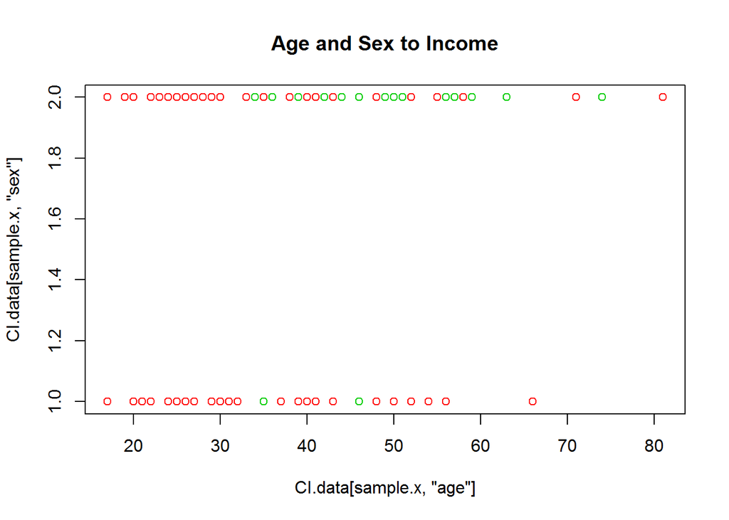

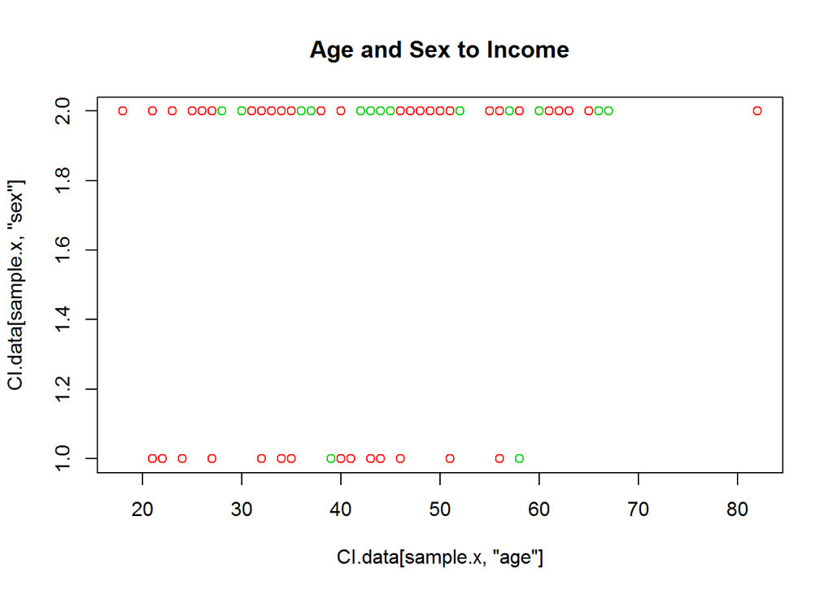

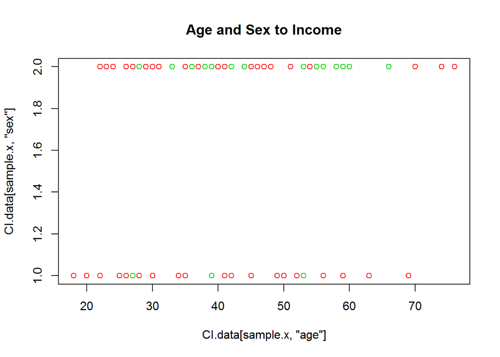

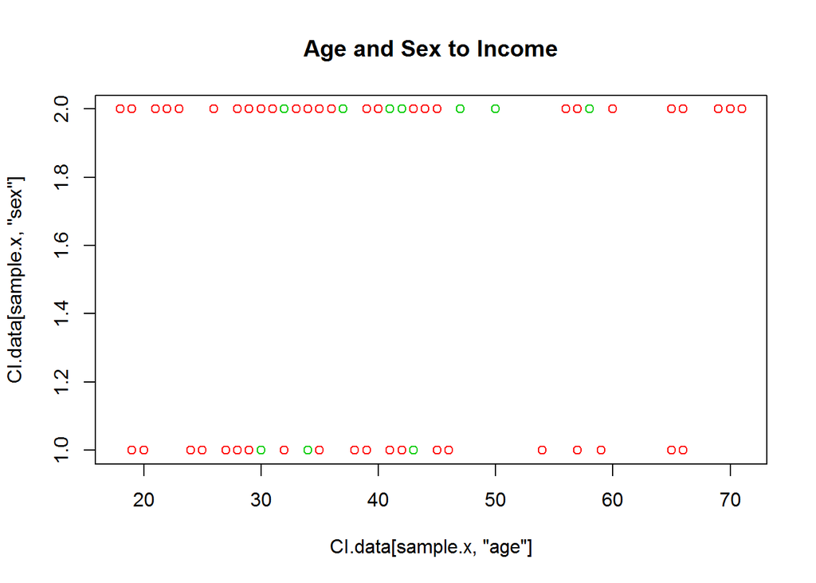

```r
for(i in 1:4){
        sample.x <- sample(1:nrow(CI.data), 100)
        plot(CI.data[sample.x, "age"], CI.data[sample.x, "sex"], col = as.numeric(CI.data[sample.x, "income"]) + 1, main = "Age and Sex to Income")
}
```

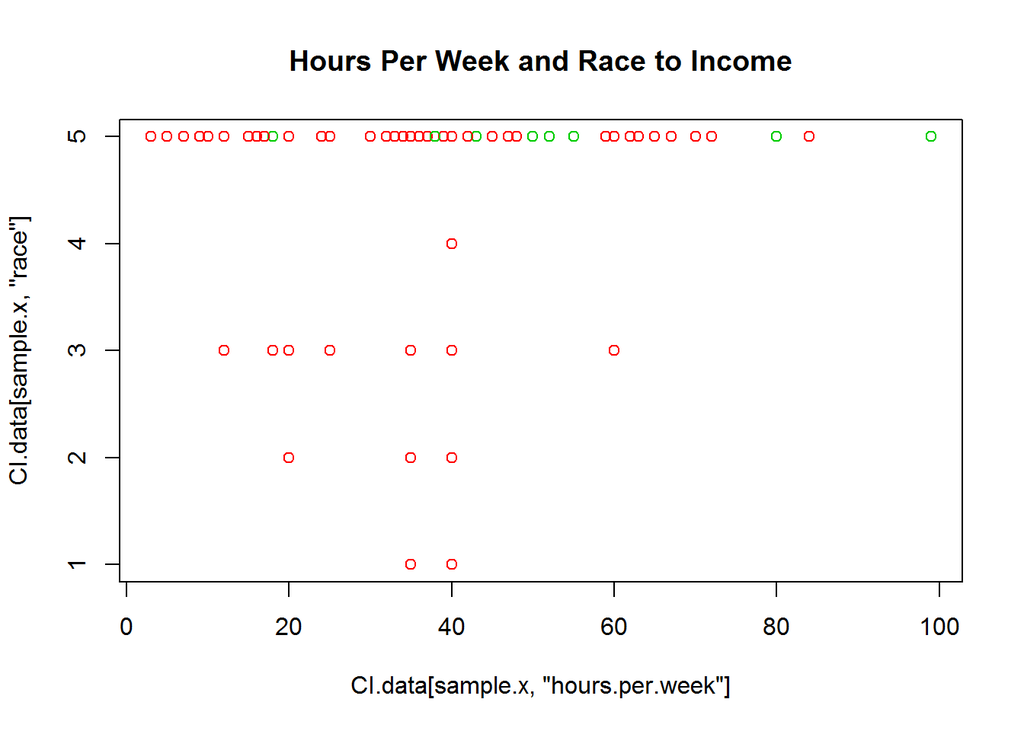

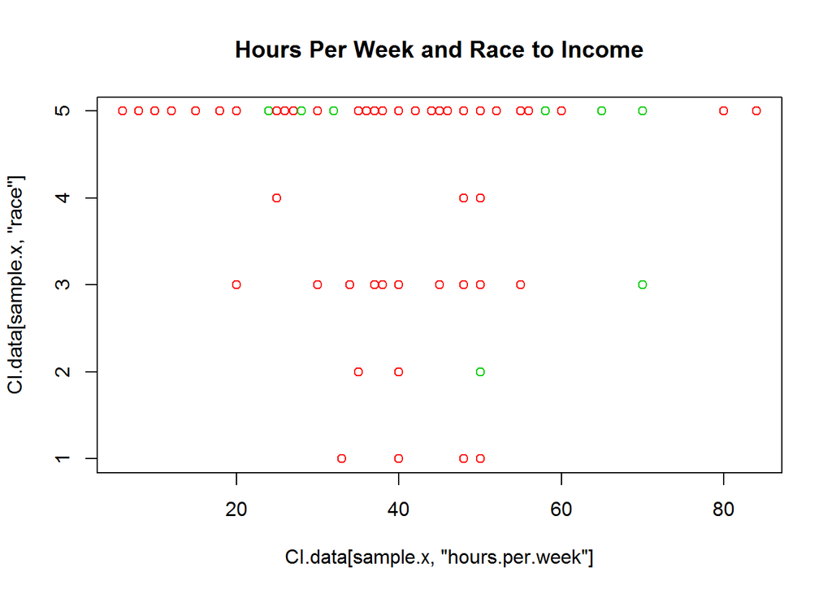

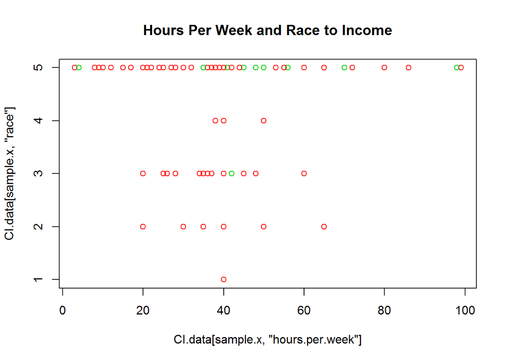

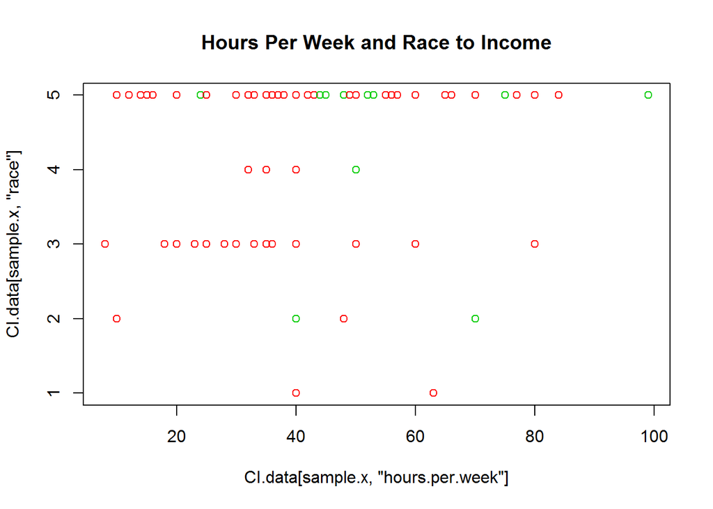

```r
for(i in 1:4){
        sample.x <- sample(1:nrow(CI.data), 400)
        plot(CI.data[sample.x, "hours.per.week"], CI.data[sample.x, "race"], col = as.numeric(CI.data[sample.x, "income"]) + 1, main = "Hours Per Week and Race to Income")
}
```

As can be seen above, older men tend to have higher incomes than younger women, and white people who work more hours per week have higher incomes than black people who work fewer hours.

```
## [1] ""
## [1] ""
## [1] "Assocication of age With Income"
```

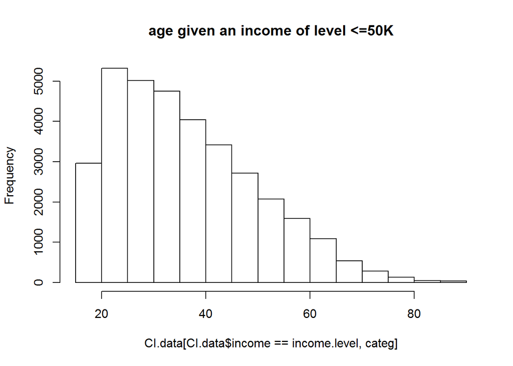

```
## $breaks
##  [1] 15 20 25 30 35 40 45 50 55 60 65 70 75 80 85 90
##
## $counts
##  [1] 2965 5313 5018 4746 4039 3412 2719 2070 1594 1086  542  289  130   50
## [15]   41
##
## $density
##  [1] 0.0174339978 0.0312400776 0.0295054977 0.0279061563 0.0237490445
##  [6] 0.0200623273 0.0159875345 0.0121714588 0.0093726113 0.0063856059
## [11] 0.0031869230 0.0016993003 0.0007643911 0.0002939966 0.0002410772
##
## $mids
##  [1] 17.5 22.5 27.5 32.5 37.5 42.5 47.5 52.5 57.5 62.5 67.5 72.5 77.5 82.5
## [15] 87.5
##
## $xname
## [1] "CI.data[CI.data$income == income.level, categ]"
##
## $equidist
## [1] TRUE
##
## attr(,"class")
## [1] "histogram"
```

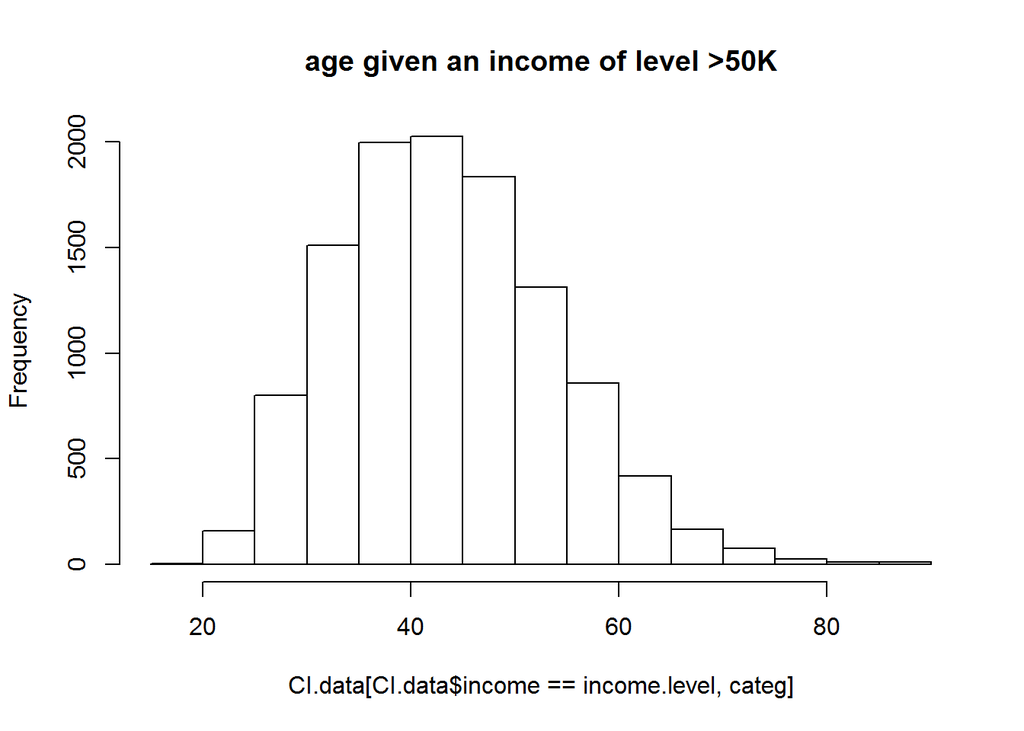

```
## $breaks
##  [1] 15 20 25 30 35 40 45 50 55 60 65 70 75 80 85 90
##
## $counts
##  [1]    3  160  801 1509 1997 2024 1835 1312  857  418  166   78   25   10
## [15]   13
##
## $density
##  [1] 5.353319e-05 2.855103e-03 1.429336e-02 2.692719e-02 3.563526e-02
##  [6] 3.611706e-02 3.274447e-02 2.341185e-02 1.529265e-02 7.458958e-03
## [11] 2.962170e-03 1.391863e-03 4.461099e-04 1.784440e-04 2.319772e-04
##
## $mids
##  [1] 17.5 22.5 27.5 32.5 37.5 42.5 47.5 52.5 57.5 62.5 67.5 72.5 77.5 82.5
## [15] 87.5
##
## $xname
## [1] "CI.data[CI.data$income == income.level, categ]"
##
## $equidist
## [1] TRUE
##
## attr(,"class")
## [1] "histogram"
## [1] ""
## [1] ""
## [1] "Assocication of work.class With Income"
##
##             ? Federal-gov Local-gov Never-worked Private Self-emp-inc
##   <=50K     0         857      2185            0   26056          734
##   >50K      0         549       915            0    7251          912
##
##         Self-emp-not-inc State-gov Without-pay
##   <=50K             2737      1426          19
##   >50K              1059       520           2
## [1] ""
## [1] ""
## [1] "Assocication of education With Income"
##
##          10th  11th  12th 1st-4th 5th-6th 7th-8th   9th Assoc-acdm
```

[output cut: 49 more lines]

```
## [1] "Assocication of race With Income"
##
##         Amer-Indian-Eskimo Asian-Pac-Islander Black Other White
##   <=50K                382                934  3694   308 28696
##   >50K                  53                369   534    45 10207
## [1] ""
## [1] ""
## [1] "Assocication of sex With Income"
##
##         Female  Male
##   <=50K  13026 20988
##   >50K    1669  9539
## [1] ""
## [1] ""
## [1] "Assocication of hours.per.week With Income"
```

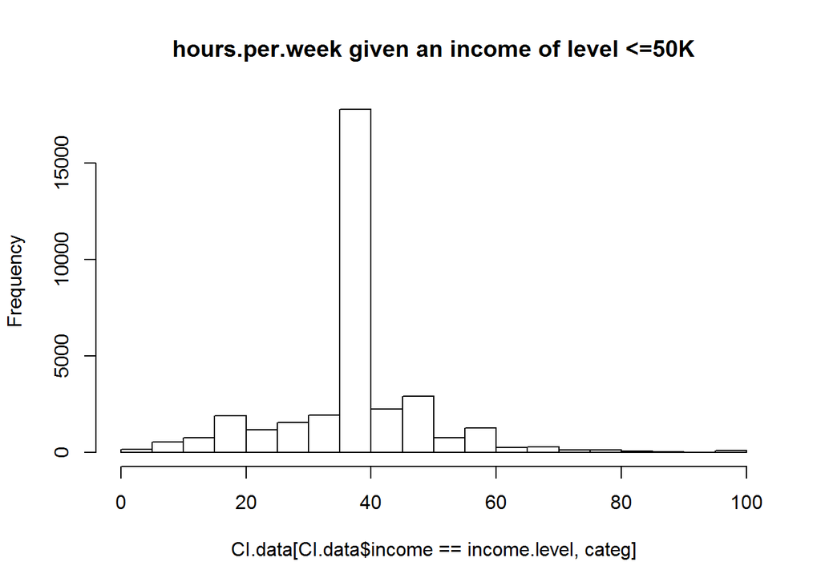

```
## $breaks
##  [1]   0   5  10  15  20  25  30  35  40  45  50  55  60  65  70  75  80
## [18]  85  90  95 100
##
## $counts
##  [1]   158   553   758  1904  1170  1562  1946 17755  2247  2915   756
## [12]  1282   249   297   130   134    56    32     7   103
##
## $density
##  [1] 9.290292e-04 3.251602e-03 4.456988e-03 1.119539e-02 6.879520e-03
##  [6] 9.184453e-03 1.144235e-02 1.043982e-01 1.321221e-02 1.714000e-02
## [11] 4.445228e-03 7.538073e-03 1.464103e-03 1.746340e-03 7.643911e-04
## [16] 7.879109e-04 3.292762e-04 1.881578e-04 4.115952e-05 6.056330e-04
##
## $mids
##  [1]  2.5  7.5 12.5 17.5 22.5 27.5 32.5 37.5 42.5 47.5 52.5 57.5 62.5 67.5
## [15] 72.5 77.5 82.5 87.5 92.5 97.5
##
## $xname
## [1] "CI.data[CI.data$income == income.level, categ]"
##
## $equidist
## [1] TRUE
##
## attr(,"class")
## [1] "histogram"
```

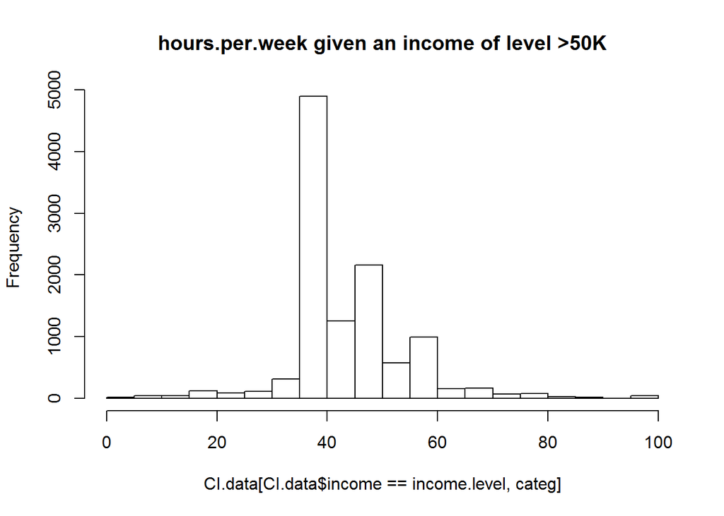

```
## $breaks
##  [1]   0   5  10  15  20  25  30  35  40  45  50  55  60  65  70  75  80
## [18]  85  90  95 100
##
## $counts
##  [1]   20   46   41  122   85  116  319 4890 1257 2157  576  998  162  166
## [15]   73   82   30   21    2   45
##
## $density
##  [1] 3.568879e-04 8.208423e-04 7.316203e-04 2.177016e-03 1.516774e-03
##  [6] 2.069950e-03 5.692363e-03 8.725910e-02 2.243041e-02 3.849036e-02
## [11] 1.027837e-02 1.780871e-02 2.890792e-03 2.962170e-03 1.302641e-03
## [16] 1.463241e-03 5.353319e-04 3.747323e-04 3.568879e-05 8.029979e-04
##
## $mids
##  [1]  2.5  7.5 12.5 17.5 22.5 27.5 32.5 37.5 42.5 47.5 52.5 57.5 62.5 67.5
## [15] 72.5 77.5 82.5 87.5 92.5 97.5
##
## $xname
## [1] "CI.data[CI.data$income == income.level, categ]"
##
## $equidist
## [1] TRUE
##
## attr(,"class")
## [1] "histogram"
```

```r
for(categ in names(CI.data)) {
        if(categ == "income") {next}
        print("")
        print("")
        print(paste("Assocication of", categ, "With Income"))
        if(class(CI.data[[categ]]) == "factor") {
                print(table(CI.data$income, CI.data[[categ]]))
        } else {
                for(income.level in levels(CI.data$income)) {
                        print(hist(CI.data[CI.data$income == income.level, categ], main = paste(categ, "given an income of level", income.level)))
                }
        }
}
```

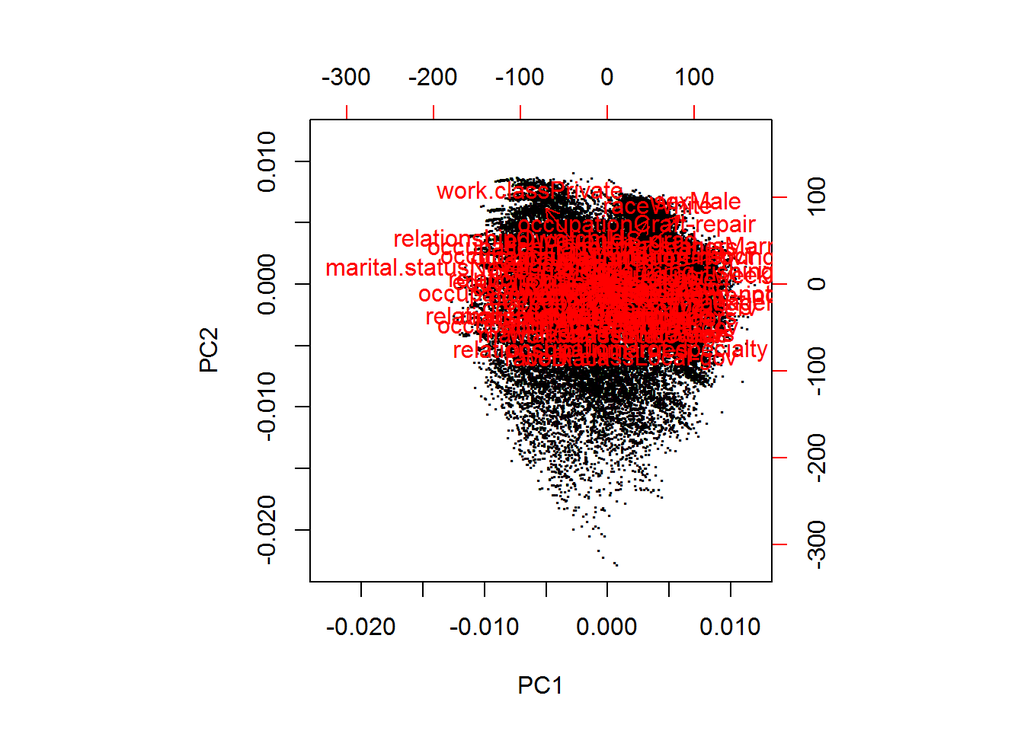

```r
# The variables are scaled because the units for numeric varables are completely different and there are dummy variables

px <- prcomp(CI.data.MM, scale = TRUE)

biplot(px, xlabs=rep(".", nrow(CI.data.MM)))
```

This biplot is too involved, so below are four biplots of only 400 sampled points and the arrows removed.

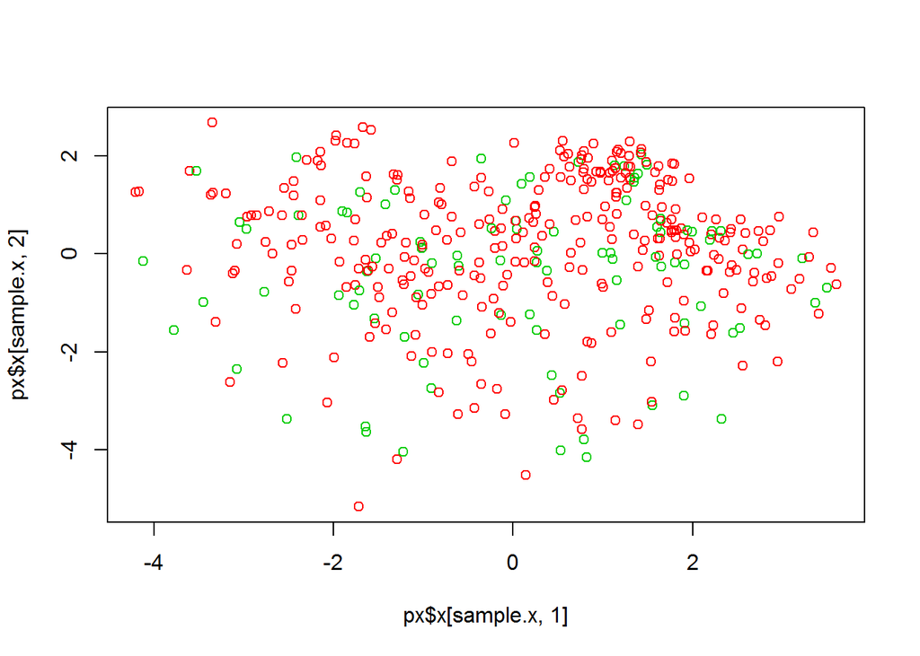

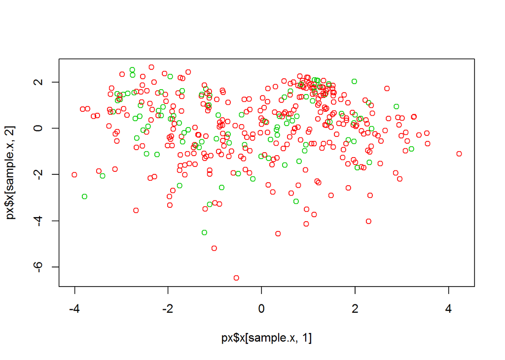

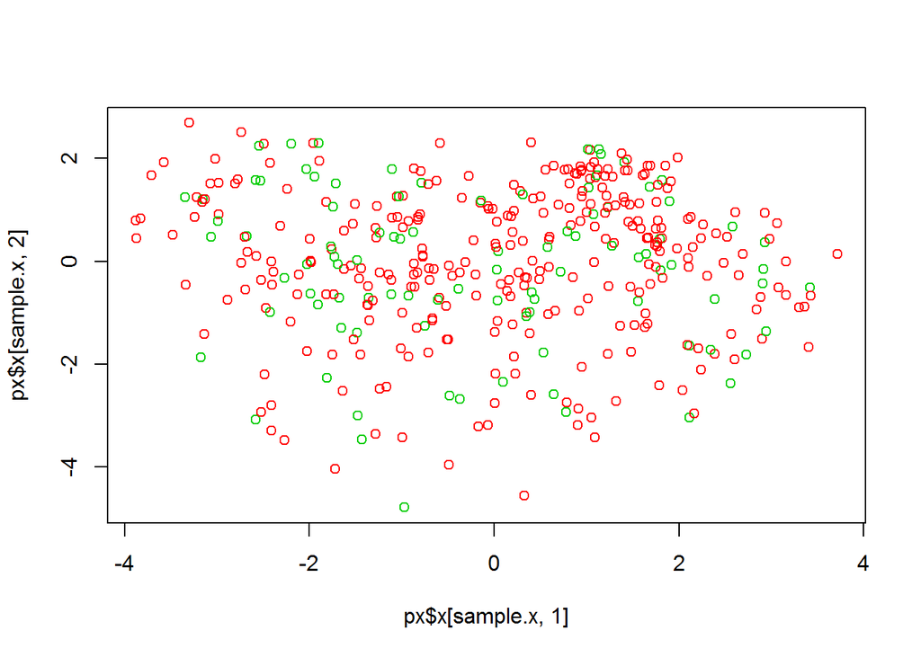

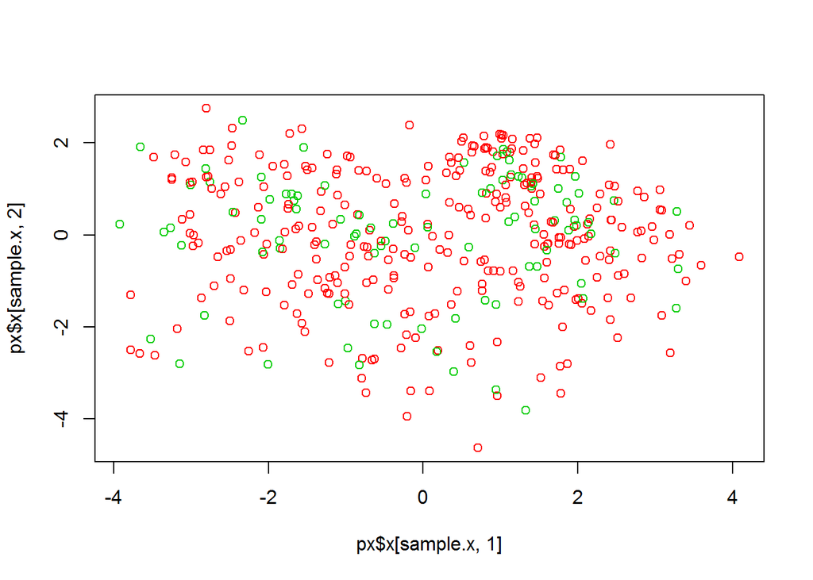

```r
for(i in 1:4){
        sample.x <- sample(1:nrow(px$x), 400)
        plot(px$x[sample.x,1],px$x[sample.x,2], col = as.numeric(CI.data$income) + 1)
}
```

```r
continuous.var.names <- character()

for(categ in names(CI.data)) {
        if(categ != "income" && class(CI.data[[categ]]) != "factor") {
                print(categ)
                categ.lm <- glm(CI.data$income ~ CI.data[[categ]], family = "binomial")
                print(summary(categ.lm))
        }
}
```

```
## [1] "age"
##
## Call:
## glm(formula = CI.data$income ~ CI.data[[categ]], family = "binomial")
##
## Deviance Residuals:
##     Min       1Q   Median       3Q      Max
## -1.5932  -0.7651  -0.6140  -0.4882   2.0560
##
## Coefficients:
##                    Estimate Std. Error z value Pr(>|z|)
## (Intercept)      -2.7671800  0.0370061  -74.78   <2e-16 ***
## CI.data[[categ]]  0.0411805  0.0008448   48.74   <2e-16 ***
## ---
## Signif. codes:  0 '***' 0.001 '**' 0.01 '*' 0.05 '.' 0.1 ' ' 1
##
## (Dispersion parameter for binomial family taken to be 1)
##
##     Null deviance: 50644  on 45221  degrees of freedom
## Residual deviance: 48146  on 45220  degrees of freedom
## AIC: 48150
##
## Number of Fisher Scoring iterations: 4
##
## [1] "hours.per.week"
##
## Call:
## glm(formula = CI.data$income ~ CI.data[[categ]], family = "binomial")
##
## Deviance Residuals:
##     Min       1Q   Median       3Q      Max
## -1.8491  -0.7193  -0.7193  -0.3296   2.4787
##
## Coefficients:
##                   Estimate Std. Error z value Pr(>|z|)
## (Intercept)      -3.070903   0.045398  -67.64   <2e-16 ***
## CI.data[[categ]]  0.046271   0.001013   45.70   <2e-16 ***
## ---
## Signif. codes:  0 '***' 0.001 '**' 0.01 '*' 0.05 '.' 0.1 ' ' 1
##
## (Dispersion parameter for binomial family taken to be 1)
##
##     Null deviance: 50644  on 45221  degrees of freedom
## Residual deviance: 48270  on 45220  degrees of freedom
## AIC: 48274
##
## Number of Fisher Scoring iterations: 4
```

# Problem 2: logistic regression (25 points)

Develop logistic regression model of the outcome as a function of multiple predictors in the model. Which variables are significantly associated with the outcome? Test model performance on multiple splits of data into training and test subsets, summarize it in terms of accuracy/error, sensitivity/specificity and compare to the performance of other methods reported in the dataset description.

The sensitivity and specificity cannot be defined because there is no null and alternative hypthesis, i.e., no “yes” or “no” outcome. However, if you arbitrarily choose <=50K as the “no” or null hypothesis and >50K as the “yes” or alternative hypothesis, then the sensitivity and specificity are as follows:

```r
iFolds <- 10
logit.accuracies <- numeric()
logit.sensitivities <- numeric()
logit.specificities <- numeric()
train <- sample(1:iFolds, nrow(CI.data), replace = TRUE)
for (iFold in 1:iFolds) {
        glm.fit <- glm(income ~ ., data = CI.data[train != iFold,], family = "binomial")
        glm.probs <- predict(glm.fit, newdata = CI.data[train == iFold,], type = "response")
        glm.pred <- rep("<=50K", sum(train == iFold))
        glm.pred[glm.probs > 0.5] <- ">50K"

        correct <- (glm.pred == CI.data[train == iFold, "income"])
        logit.accuracies[iFold] <- sum(correct)*100/length(CI.data[train == iFold, "income"])
        TP <- sum(CI.data[train == iFold, "income"] == ">50K" & glm.pred == ">50K")
        TN <- sum(CI.data[train == iFold, "income"] == "<=50K" & glm.pred == "<=50K")
        FP <- sum(CI.data[train == iFold, "income"] == "<=50K"  & glm.pred == ">50K")
        FN <- sum(CI.data[train == iFold, "income"] == ">50K" & glm.pred == "<=50K")
        P <- TP + FN
        N <- TN + FP
## TP/FP true/false positives (predicted >50K)
## TN/FN true/false negatives (predicted <=50K)

        logit.sensitivities[iFold] <- 100*TP/P
        logit.specificities[iFold] <- 100*TN/N
}

print("Accuracy for each fold")
```

```
## [1] "Accuracy for each fold"
```

```r
print(logit.accuracies)
```

```
##  [1] 82.92843 84.67742 83.03591 83.10144 83.75141 82.86729 83.41589
##  [8] 82.96885 82.65443 82.40391
```

```r
print("Average accuracy")
```

```
## [1] "Average accuracy"
```

```r
print(mean(logit.accuracies))
```

```
## [1] 83.1805
```

```r
print("Sensitivity for each fold")
```

```
## [1] "Sensitivity for each fold"
```

```r
print(logit.sensitivities)
```

```
##  [1] 55.13608 58.04968 56.05920 55.25830 59.18367 54.82417 56.06061
##  [8] 56.81818 55.92784 57.41667
```

```r
print("Average sensitivity")
```

```
## [1] "Average sensitivity"
```

```r
print(mean(logit.sensitivities))
```

```
## [1] 56.47344
```

```r
print("Specificity for each fold")
```

```
## [1] "Specificity for each fold"
```

```r
print(logit.specificities)
```

```
##  [1] 92.15743 92.94487 91.46906 92.05219 91.66418 92.02237 92.13292
##  [8] 91.81200 92.07022 91.48743
```

```r
print("Average specificity")
```

```
## [1] "Average specificity"
```

```r
print(mean(logit.specificities))
```

```
## [1] 91.98127
```

Above are the average accuracy, sensitivity, and specificity for the logistic fit after K-fold cross-validation.

```r
summary(glm.fit)
```

```
##
## Call:
## glm(formula = income ~ ., family = "binomial", data = CI.data[train !=
##     iFold, ])
##
## Deviance Residuals:
##     Min       1Q   Median       3Q      Max
## -2.7190  -0.5704  -0.2235  -0.0333   3.6307
##
## Coefficients:
##                                      Estimate Std. Error z value Pr(>|z|)
## (Intercept)                         -7.201907   0.345184 -20.864  < 2e-16
## age                                  0.028927   0.001395  20.740  < 2e-16
## work.classLocal-gov                 -0.637932   0.093274  -6.839 7.96e-12
## work.classPrivate                   -0.475379   0.077480  -6.136 8.49e-10
## work.classSelf-emp-inc              -0.243147   0.100975  -2.408  0.01604
## work.classSelf-emp-not-inc          -0.975078   0.090514 -10.773  < 2e-16
## work.classState-gov                 -0.879195   0.102786  -8.554  < 2e-16
## work.classWithout-pay               -1.433655   0.800816  -1.790  0.07341
## education11th                        0.279825   0.184204   1.519  0.12874
## education12th                        0.590795   0.226639   2.607  0.00914
## education1st-4th                    -0.682262   0.417666  -1.634  0.10236
## education5th-6th                    -0.203184   0.270734  -0.750  0.45296
## education7th-8th                    -0.355090   0.204866  -1.733  0.08305
## education9th                        -0.201519   0.228215  -0.883  0.37722
## educationAssoc-acdm                  1.551741   0.155256   9.995  < 2e-16
## educationAssoc-voc                   1.507581   0.149796  10.064  < 2e-16
## educationBachelors                   2.201746   0.140604  15.659  < 2e-16
## educationDoctorate                   3.169849   0.186544  16.993  < 2e-16
## educationHS-grad                     1.001396   0.137391   7.289 3.13e-13
## educationMasters                     2.548816   0.148530  17.160  < 2e-16
## educationPreschool                  -1.121749   1.029822  -1.089  0.27604
## educationProf-school                 3.293283   0.176873  18.620  < 2e-16
## educationSome-college                1.384080   0.139115   9.949  < 2e-16
## marital.statusMarried-AF-spouse      2.346026   0.487640   4.811 1.50e-06
## marital.statusMarried-civ-spouse     2.146682   0.223136   9.620  < 2e-16
## marital.statusMarried-spouse-absent  0.114891   0.179306   0.641  0.52168
## marital.statusNever-married         -0.440613   0.070392  -6.259 3.86e-10
## marital.statusSeparated              0.054899   0.127769   0.430  0.66743
## marital.statusWidowed                0.086301   0.123192   0.701  0.48359
```

[output cut: 73 more lines]

```
## raceBlack                           *
## raceOther
## raceWhite                           **
## sexMale                             ***
## hours.per.week                      ***
## ---
## Signif. codes:  0 '***' 0.001 '**' 0.01 '*' 0.05 '.' 0.1 ' ' 1
##
## (Dispersion parameter for binomial family taken to be 1)
##
##     Null deviance: 45415  on 40720  degrees of freedom
## Residual deviance: 29029  on 40668  degrees of freedom
## AIC: 29135
##
## Number of Fisher Scoring iterations: 7
```

From the above summary, it seems that all variables were relevant in predicting income. Notably, other race and black race were less relevant. This may be because for the most part, being black and being white are colinear. With the few exceptions of the other three races, if one person is not white in the data, he/she is likely black.

# Problem 3: random forest (25 points)

Develop random forest model of the categorized income. Present variable importance plots and comment on relative importance of different attributes in the model. Did attributes showing up as more important in random forest model also appear as significantly associated with the outcome by logistic regression? Test model performance on multiple splits of data into training and test subsets, compare test and out-of-bag error estimates, summarize model performance in terms of accuracy/error, sensitivity/specificity and compare to the performance of other methods reported in the dataset description.

```r
library(randomForest)
iFolds <- 10
rf.accuracies <- numeric()
rf.sensitivities <- numeric()
rf.specificities <- numeric()
train <- sample(1:iFolds, nrow(CI.data), replace = TRUE)

for (iFold in 1:iFolds) {
        rf.fit <- randomForest(income ~ ., data = CI.data[train != iFold,], importance = TRUE, ntree = 50)
        rf.pred <- predict(rf.fit, newdata = CI.data[train == iFold,])

        correct <- (rf.pred == CI.data[train == iFold, "income"])
        rf.accuracies[iFold] <- sum(correct)*100/length(CI.data[train == iFold, "income"])
        TP <- sum(CI.data[train == iFold, "income"] == ">50K" & rf.pred == ">50K")
        TN <- sum(CI.data[train == iFold, "income"] == "<=50K" & rf.pred == "<=50K")
        FP <- sum(CI.data[train == iFold, "income"] == "<=50K"  & rf.pred == ">50K")
        FN <- sum(CI.data[train == iFold, "income"] == ">50K" & rf.pred == "<=50K")
        P <- TP + FN
        N <- TN + FP
## TP/FP true/false positives (predicted >50K)
## TN/FN true/false negatives (predicted <=50K)

        rf.sensitivities[iFold] <- 100*TP/P
        rf.specificities[iFold] <- 100*TN/N
}

print("Accuracy for each fold")
```

```
## [1] "Accuracy for each fold"
```

```r
print(rf.accuracies)
```

```
##  [1] 82.71028 83.17159 83.85201 83.13488 82.36866 83.34450 83.31477
##  [8] 83.32963 83.38128 83.31853
```

```r
print("Average accuracy")
```

```
## [1] "Average accuracy"
```

```r
print(mean(rf.accuracies))
```

```
## [1] 83.19261
```

```r
print("Sensitivity for each fold")
```

```
## [1] "Sensitivity for each fold"
```

```r
print(rf.sensitivities)
```

```
##  [1] 58.79265 59.31759 60.12489 59.81308 57.09251 59.63134 58.62069
##  [8] 60.80074 58.91043 60.30466
```

```r
print("Average sensitivity")
```

```
## [1] "Average sensitivity"
```

```r
print(mean(rf.sensitivities))
```

```
## [1] 59.34086
```

```r
print("Specificity for each fold")
```

```
## [1] "Specificity for each fold"
```

```r
print(rf.specificities)
```

```
##  [1] 90.86840 91.21203 91.50835 91.10982 90.91451 90.92516 91.63192
##  [8] 90.39416 91.09430 90.90372
```

```r
print("Average specificity")
```

```
## [1] "Average specificity"
```

```r
print(mean(rf.specificities))
```

```
## [1] 91.05624
```

```r
## The following is based on OOB data rather than K-fold cross-validation.  Since these were not used in making the random forest model, they are in fact a better measure of the test error

rf.oob.sensitivity <- 1 - rf.fit$confusion[[">50K", "class.error"]]
rf.oob.specificity <- 1 - rf.fit$confusion[["<=50K", "class.error"]]
rf.oob.accuracy <- sum(diag(rf.fit$confusion[1:2,1:2]))/sum(colSums(rf.fit$confusion[,1:2]))
print(paste("Random Forest OOB Sensitivity:", rf.oob.sensitivity))
```

```
## [1] "Random Forest OOB Sensitivity: 0.588684106222751"
```

```r
print(paste("Random Forest OOB Specificity:", rf.oob.specificity))
```

```
## [1] "Random Forest OOB Specificity: 0.907470288624788"
```

```r
print(paste("Random Forest OOB Accuracy", rf.oob.accuracy))
```

```
## [1] "Random Forest OOB Accuracy 0.828462671905697"
```

As shown above, the OOB accuracy is very similar to the cross-validation accuracy, further demonstrating the quality of this model.

```r
importance(rf.fit)
```

```
##                    <=50K       >50K MeanDecreaseAccuracy MeanDecreaseGini
## age             4.046329 38.8105175            39.363699        2138.5873
## work.class     22.127083  7.6083779            24.194242         607.2254
## education      29.574959 42.6858319            51.840675        1767.9740
## marital.status 33.049795  7.9063290            20.078292        1671.8657
## occupation     24.076329 35.7319059            47.254569        1550.9529
## relationship    8.677970 12.8846843            12.219739        1412.2890
## race            3.718223  3.5136546             5.319199         274.8251
## sex            17.114419  0.8858381            18.977846         195.0687
## hours.per.week  3.715348 28.6623632            24.723825        1241.2454
```

# Problem 4: SVM (25 points)

Develop SVM model of this data choosing parameters (e.g. choice of kernel, cost, etc.) that appear to yield better performance. Test model performance on multiple splits of data into training and test subsets, summarize model performance in terms of accuracy/error, sensitivity/specificity and compare to the performance of other methods reported in the dataset description.

```r
library(e1071)

svm.accuracies <- numeric()
svm.sensitivities <- numeric()
svm.specificities <- numeric()

for (i in 1:3) {
        train <- sample(1:nrow(CI.data), 1000)
        svm.fit <- tune(svm, income ~ ., data = CI.data[train,], kernel = "radial")$best.model
        svm.pred <- predict(svm.fit, CI.data[-train,])

        correct <- (svm.pred == CI.data[-train, "income"])
        svm.accuracies[i] <- sum(correct)*100/length(CI.data[-train, "income"])
        TP <- sum(CI.data[-train, "income"] == ">50K" & svm.pred == ">50K")
        TN <- sum(CI.data[-train, "income"] == "<=50K" & svm.pred == "<=50K")
        FP <- sum(CI.data[-train, "income"] == "<=50K"  & svm.pred == ">50K")
        FN <- sum(CI.data[-train, "income"] == ">50K" & svm.pred == "<=50K")
        P <- TP + FN
        N <- TN + FP
## TP/FP true/false positives (predicted >50K)
## TN/FN true/false negatives (predicted <=50K)

        svm.sensitivities[i] <- 100*TP/P
        svm.specificities[i] <- 100*TN/N
}

print("Accuracy for each fold")
```

```
## [1] "Accuracy for each fold"
```

```r
print(svm.accuracies)
```

```
## [1] 78.43155 82.36172 82.55619
```

```r
print("Average accuracy")
```

```
## [1] "Average accuracy"
```

```r
print(mean(svm.accuracies))
```

```
## [1] 81.11649
```

```r
print("Sensitivity for each fold")
```

```
## [1] "Sensitivity for each fold"
```

```r
print(svm.sensitivities)
```

```
## [1] 16.83520 49.54321 50.25098
```

```r
print("Average sensitivity")
```

```
## [1] "Average sensitivity"
```

```r
print(mean(svm.sensitivities))
```

```
## [1] 38.87646
```

```r
print("Specificity for each fold")
```

```
## [1] "Specificity for each fold"
```

```r
print(svm.specificities)
```

```
## [1] 98.76974 93.15723 93.19705
```

```r
print("Average specificity")
```

```
## [1] "Average specificity"
```

```r
print(mean(svm.specificities))
```

```
## [1] 95.04134
```

# Problem 5: compare logistic regression, random forest and SVM model performance (5 points)

Compare performance of the models developed above (logistic regression, random forest, SVM) in terms of their accuracy, error and sensitivity/specificity. Comment on differences and similarities between them.

# Extra 10 points: KNN model

Develop KNN model for this data, evaluate its performance for different values of $k$ on different splits of the data into training and test and compare it to the performance of other methods reported in the dataset description. Notice that this dataset includes many categorical variables as well as continuous attributes measured on different scales, so that the distance has to be defined to be meaningful (probably avoiding subtraction of the numerical values of multi-level factors directly or adding differences between untransformed age and capital gain/loss attributes).

# Extra 15 points: variable importance in SVM

SVM does not appear to provide readily available tools for judging relative importance of different attributes in the model. Please evaluate here an approach similar to that employed by random forest where importance of any given attribute is measured by the decrease in model performance upon randomization of the values for this attribute.